# PA1_template

## *Imputing missing values*

1. *Calculate and report the total number of missing values in the dataset*

```r
NA.vals <- sum(is.na(activity$steps))
```

Missing Value Count: **2304**

2. *Devise a strategy for filling in all of the missing values in the dataset.* I will fill in missing data with the mean number of steps across all days with available data for that particular interval.

The missing data will be filled in with the mean number of steps from all days with availavble data per respective interval

3. *Create a new dataset that is equal to the original dataset but with the missing data filled in*

```r
Step_Interval <- tapply(activity$steps, activity$interval, mean, na.rm = TRUE)

# Acivity split by the data interval
activity.split <- split(activity, activity$interval)

# Missing data filled in for each respective interval
for(i in 1:length(activity.split)){
  activity.split[[i]]$steps[is.na(activity.split[[i]]$steps)] <- Step_Interval[i]
}

activity.imputed <- do.call("rbind", activity.split)
activity.imputed <- activity.imputed[order(activity.imputed$date) ,]
```

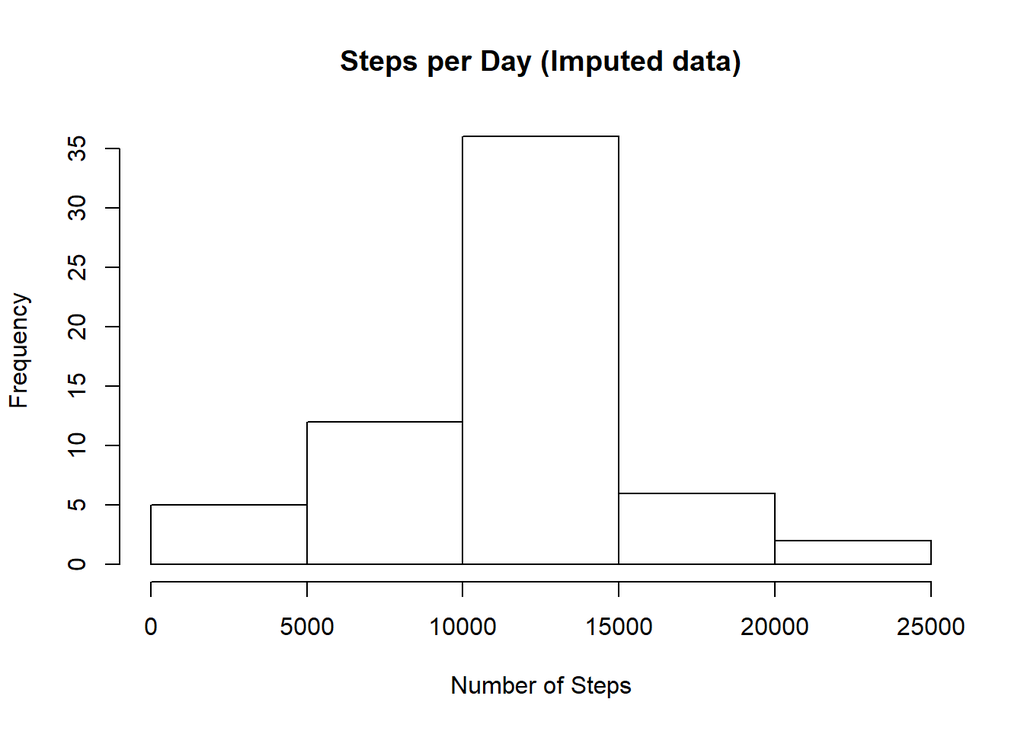

```r
Steps_per_day.imputed <- tapply(activity.imputed$steps, activity.imputed$date, sum)
hist(Steps_per_day.imputed, xlab = "Number of Steps", main = "Steps per Day (Imputed data)")
```

```r
Mean_Day.imputed <- mean(Steps_per_day.imputed, na.rm = TRUE)
Median_Day.imputed <- median(Steps_per_day.imputed, na.rm = TRUE)
```

## *Are there differences in activity patterns between weekdays and weekends?*

1. *Create a new factor variable in the dataset with two levels - “weekday” and “weekend” indicating whether a given date is a weekday or weekend day.*

```r
activity.imputed$day <- ifelse(
                          weekdays(as.Date(activity.imputed$date)) == "Saturday" |
                          weekdays(as.Date(activity.imputed$date)) == "Sunday", "weekend", "weekday"
                              )
```

2. *Make a panel plot containing a time series plot of the 5-minute interval (x-axis) and the average number of steps taken, averaged across all weekday days or weekend days (y-axis).*

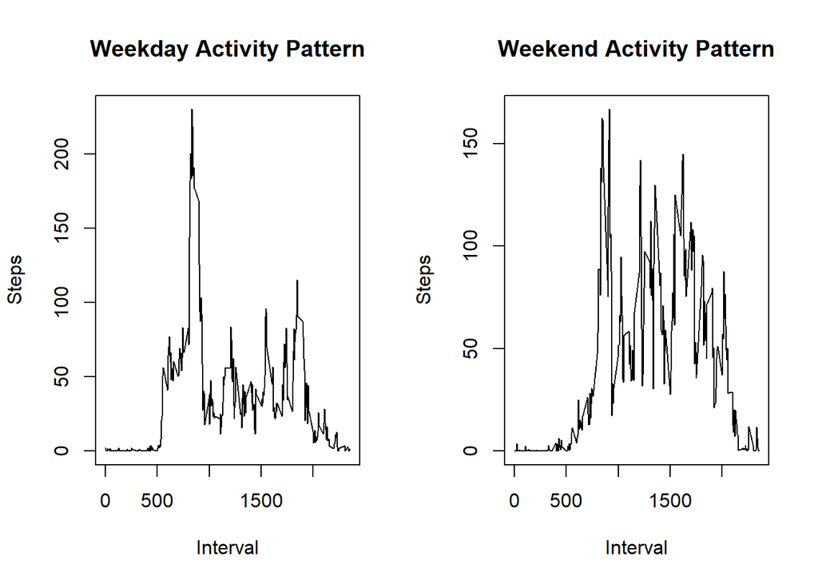

```r
# Calculate avg steps per interval for weekends
Step_Interval.weekend <- tapply(
                                   activity.imputed[activity.imputed$day == "weekend" ,]$steps,
                                   activity.imputed[activity.imputed$day == "weekend" ,]$interval,
                                   mean,
                                   na.rm = TRUE)

# Calculate avg steps per interval for weekdays
Step_Interval.weekday <- tapply(
                                   activity.imputed[activity.imputed$day == "weekday" ,]$steps,
                                   activity.imputed[activity.imputed$day == "weekday" ,]$interval,
                                   mean,
                                   na.rm = TRUE)

# 2 Panel Plot set
par(mfrow=c(1,2))

# Weekday
plot(as.numeric(names(Step_Interval.weekday)),
     Step_Interval.weekday,
     xlab = "Interval",
     ylab = "Steps",
     main = "Weekday Activity Pattern",
     type = "l")

# Weekend
plot(as.numeric(names(Step_Interval.weekend)),
     Step_Interval.weekend,
     xlab = "Interval",
     ylab = "Steps",
     main = "Weekend Activity Pattern",
     type = "l")
```